# Introduction to Planned Contrast Analysis

Why You Should Stop Relying on ANOVA Alone — and What to Do Instead

```r
library(contrastanalysis)
library(MASS)
library(ggplot2)
```

# 1 You Have a Theory. ANOVA Can’t Test It.

Imagine you run an experiment. You randomly assign participants to four conditions. You have a clear, specific prediction about what the results should look like: you expect the dependent variable to increase steadily from the first condition to the last.

So you collect your data, run an ANOVA, and get a significant *F*-test. Great — right?

Not so fast. The ANOVA tells you that **at least two group means are different**. That’s it. It doesn’t tell you whether they differ *in the way you predicted*. Maybe the first three groups are flat and only the last one jumps up. Maybe the pattern is U-shaped. Maybe it’s completely random. A significant *F* cannot distinguish between any of these possibilities.

Let’s make this concrete with a visualization.

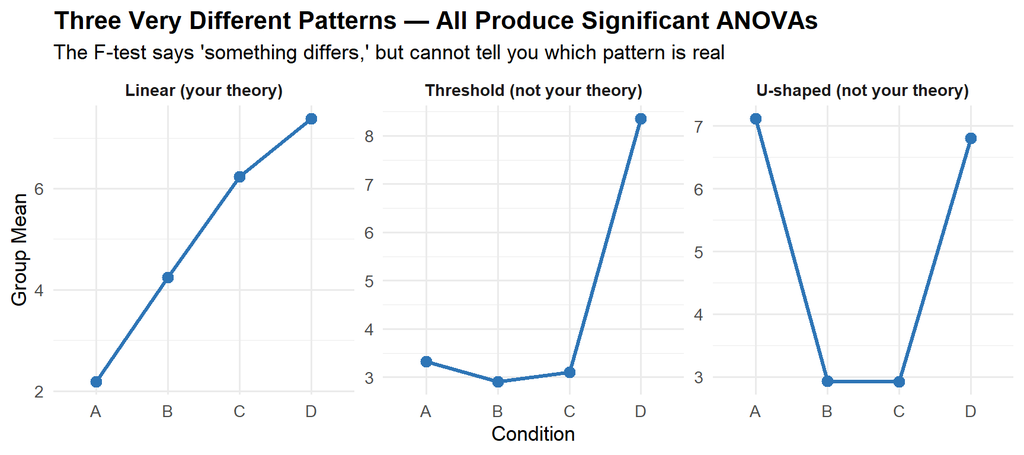

All three panels above would produce a statistically significant ANOVA. But only the first one matches your theory. The ANOVA treats all three as the same outcome: “*p* < .05, at least two means differ.” It’s blind to shape.

This is the fundamental limitation of the omnibus *F*-test: **it’s a fire alarm that tells you there’s a fire somewhere in the building, but it can’t tell you which room**.

# 2 Strategy 1: “Just Look at the Means” — The Eyeballing Trap

Faced with a significant ANOVA, many researchers simply look at the group means and declare that the pattern matches their theory. The logic goes: “The ANOVA is significant, and the means *look like* they go up, so my linear hypothesis is supported.”

This sounds intuitive, but it is **statistically indefensible**. You have not actually tested whether the pattern is linear — you have tested whether *something* differs, and then you *assumed* it differed in the way you expected. This is the difference between testing a hypothesis and narrating one.

Let’s see how badly this can go wrong with two detailed examples.

## 2.1 Example A: The hidden plateau

A researcher predicts that increasing the difficulty of a cognitive task (Low, Medium, Hard, Extreme) will produce a linear increase in response time. She runs the experiment with 50 participants per group.

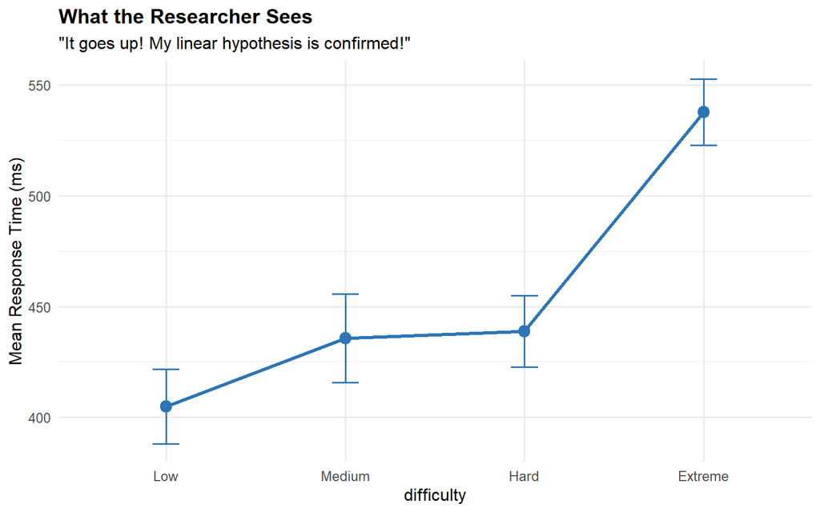

The ANOVA is significant:

```r
summary(aov(rt ~ difficulty, data = plateau_data))
```

```
##              Df Sum Sq Mean Sq F value Pr(>F)
## difficulty    3 499670  166557   43.88 <2e-16 ***
## Residuals   196 744032    3796
## ---
## Signif. codes:  0 '***' 0.001 '**' 0.01 '*' 0.05 '.' 0.1 ' ' 1
```

The means go up. A researcher who “eyeballs” the pattern would write: *“The ANOVA revealed a significant main effect of difficulty, F(3, 196) = …, p < .001. As predicted, response time increased linearly across the four difficulty levels.”*

But that conclusion is **wrong**. The true pattern is not linear — it is a **plateau followed by a jump**. Medium and Hard are nearly identical, and the entire ANOVA is being driven by the Extreme condition. The researcher’s linear theory does not describe these data. She just didn’t test it.

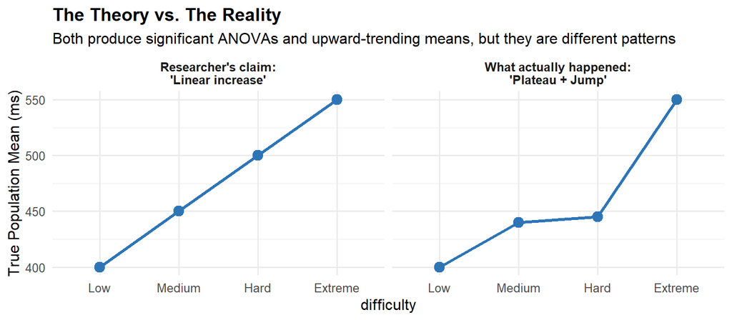

The left panel shows what the researcher *claims* happened (a clean linear staircase). The right panel shows the actual generating process (a plateau with a late spike). They are qualitatively different theories — one implies that difficulty has a continuous, proportional effect on cognition; the other implies a threshold or bottleneck. Eyeballing cannot distinguish between them.

## 2.2 Example B: The reversed middle

A developmental psychologist hypothesizes that children’s reading fluency increases linearly from ages 6 to 9 (four age groups). She collects data and gets a significant ANOVA.

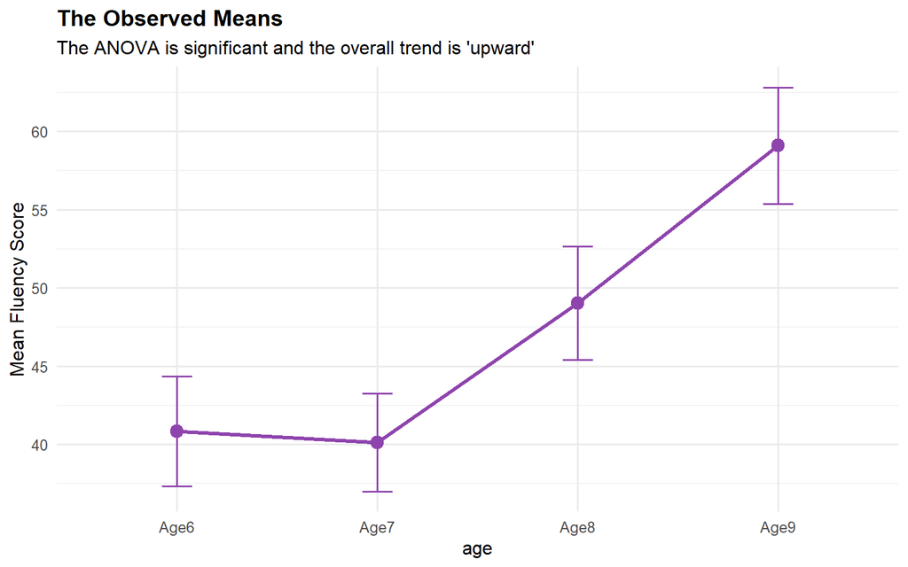

```r
summary(aov(fluency ~ age, data = reversed_data))
```

```
##              Df Sum Sq Mean Sq F value   Pr(>F)
## age           3  10587    3529   24.57 2.51e-13 ***
## Residuals   176  25283     144
## ---
## Signif. codes:  0 '***' 0.001 '**' 0.01 '*' 0.05 '.' 0.1 ' ' 1
```

Again, the ANOVA is significant, and the means trend upward *overall*. A researcher who glances at the means might write: *“Reading fluency increased significantly across the four age groups, supporting a linear developmental trajectory.”*

But Age 7 is actually *lower* than Age 6. There is a dip in the middle of what should be a monotonic trend. This could reflect a real developmental phenomenon (perhaps a reorganization period), or it could be a methodological problem in the Age 7 group. Either way, the linear claim is **wrong**, and the eyeballing approach failed to catch it.

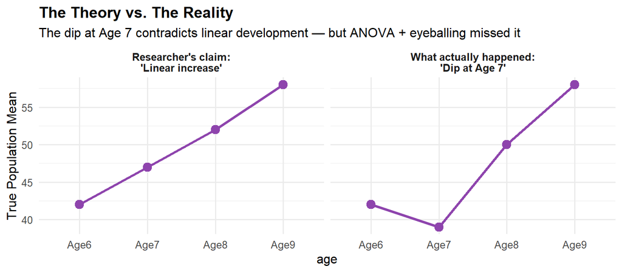

## 2.3 Why eyeballing fails

These examples are not contrived. The core problem is that **looking at means and describing what you see is not a statistical test**. It is narration. You are fitting a story to noise, with no formal evaluation of whether the story actually fits. Specifically:

1. **Sampling variability is invisible to the eye.** With noisy data, group means can look linearly ordered even when the true population pattern is very different. The error bars might overlap in ways that matter, but “it goes up” is all the eye can see.
2. **The ANOVA offers no protection.** A significant *F* only confirms that the means are not *all equal*. It does not confirm that they follow any particular shape. Using ANOVA significance to license a pattern claim is a logical non sequitur.
3. **You can’t fail.** There is no scenario in which eyeballing would lead a researcher to reject their own theory. If the means roughly go up, they say “linear.” If one group is a bit off, they ignore it or explain it away. This is not hypothesis testing — it is confirmation bias dressed up as data analysis.

The solution is to actually **test the pattern**, not just look at it. That is what contrast analysis does. But first, let’s examine the other common strategy.

# 3 Strategy 2: ANOVA + Post-Hoc Tests — Valid But Wasteful

The second common approach is to follow a significant ANOVA with **post-hoc tests** — pairwise comparisons between all groups. Unlike eyeballing, this is a legitimate statistical procedure. Each comparison has a proper test statistic and *p*-value. But it has serious limitations when your goal is to test a specific predicted pattern.

With *k* groups, post-hoc testing means *k*(*k* − 1) / 2 comparisons. For four groups, that’s six separate tests. For six groups, it’s fifteen.

There are two problems with this approach.

**Problem 1: You’re testing things you don’t care about.** If your theory predicts a linear trend, you don’t need to know whether group B differs from group D. You need to know whether the overall *shape* of the data matches your prediction. Post-hoc tests break your focused theoretical question into fragments and scatter your statistical power across irrelevant comparisons.

**Problem 2: Correction penalties eat your power.** Because you’re running multiple tests, you need to correct for familywise error (e.g., Bonferroni, Tukey). These corrections raise the bar for significance, making it harder to detect real effects — especially in the comparisons you actually care about.

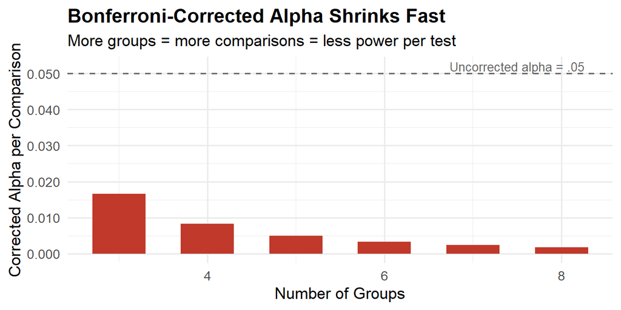

To summarize: **ANOVA + post-hoc testing is a valid approach, but it is not designed to answer the question “does the pattern of means match my specific prediction?”** It answers a different question — “which pairs of groups differ?” — and pays a heavy statistical price for doing so.

# 4 The Solution: Planned Contrast Analysis

Contrast analysis takes a completely different approach. Instead of asking “which groups differ?”, it asks: **“Does the pattern of means match my specific prediction?”**

The idea is beautifully simple. You start with a theory — a prediction about the *shape* of the results. Then you translate that prediction into a set of numerical **weights** (one per group) that encode the expected pattern. The analysis tests whether the data follow that pattern.

## 4.1 What are contrast weights?

Contrast weights are numbers you assign to each condition that describe your predicted pattern. They must sum to zero (this centers the contrast around “no effect”). Here are some examples:

Table 4.1: Examples of contrast weights for different predictions

| Prediction | A | B | C | D |
| --- | --- | --- | --- | --- |
| Linear increase: A < B < C < D | -3 | -1 | 1 | 3 |
| Treatment vs. Control: [A = B = C] > D | 1 | 1 | 1 | -3 |
| Step function: [A = B] < [C = D] | -1 | -1 | 1 | 1 |
| Quadratic (inverted U): A < [B = C] > D | -1 | 1 | 1 | -1 |

The key insight is that **only the relative spacing matters**. Weights of (−3, −1, 1, 3) and (0, 1, 2, 3) both encode the same linear trend — the function normalizes them internally.

## 4.2 What makes this better than ANOVA + post-hoc?

Planned contrasts have three major advantages.

**1. They directly test your theory.** Instead of six fragmentary pairwise comparisons, you get one focused test: “Is the predicted pattern present?” This is what you actually wanted to know.

**2. They use all your data at once.** A single contrast test uses information from all *k* groups simultaneously, giving it more statistical power than any individual pairwise comparison.

**3. No multiple comparison penalty (when contrasts are orthogonal).** If you build a complete set of orthogonal contrasts — one for your prediction plus residuals that cover the remaining degrees of freedom — the tests are statistically independent. No correction needed.

# 5 The Two Halves of Contrast Analysis

A complete contrast analysis has two parts. Understanding both is essential.

## 5.1 Part 1: The Contrast of Interest

This tests your prediction. You supply the weights, and the analysis asks: “Is there a statistically significant trend in the direction I predicted?” This is a standard null hypothesis significance test (NHST). If *p* < .05, the predicted pattern is present in the data.

## 5.2 Part 2: The Residual Contrasts

This is where most tutorials stop — and that’s a problem. Even if your predicted pattern is significant, there might also be *other* patterns in the data that your theory doesn’t account for. The residual contrasts capture **everything your prediction doesn’t explain**.

With *k* groups, you have *k* − 1 total degrees of freedom among the group means. Your contrast of interest uses 1 df, leaving *k* − 2 residual contrasts. These are automatically computed to be orthogonal to your prediction.

Think of it this way: if your theory says the data should be a straight line, the residuals capture any curvature, bumps, or irregularities in the actual pattern.

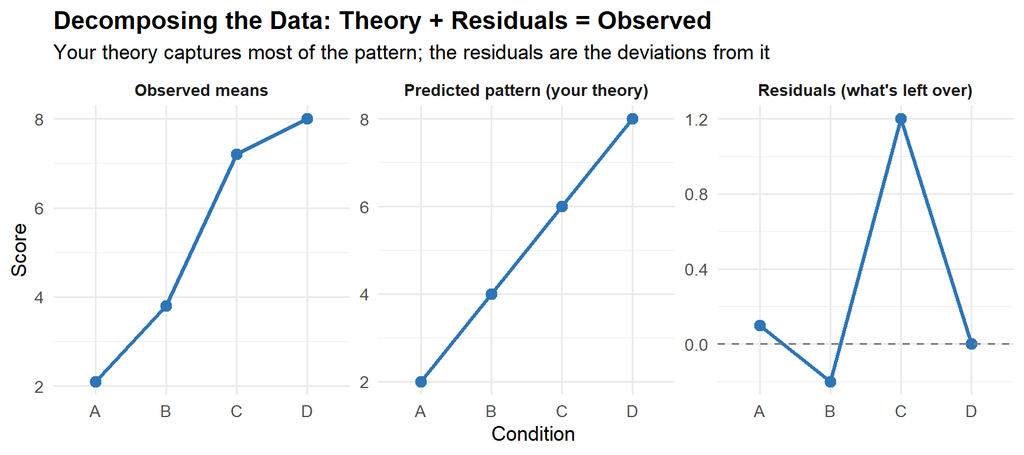

# 6 The Traditional C+R Approach — and Its Fatal Flaw

The traditional “Contrast + Residual” (C+R) approach tests both halves using null hypothesis significance testing. The logic goes:

1. If the contrast of interest is significant → the predicted pattern exists.
2. If the residual contrasts are *not* significant → no meaningful deviations exist.
3. Therefore, the predicted pattern *fully accounts* for the data.

This sounds reasonable, but step 2 contains a **logical fallacy**: it confuses absence of evidence with evidence of absence. A non-significant residual could mean the residual is truly negligible, but it could also mean you simply didn’t have enough statistical power to detect it.

Richter (2016) formalized this critique. He showed that when sample sizes are small or residual effects are modest, traditional NHST-based residual tests have dangerously low power. In practice, researchers routinely “confirm” their predicted patterns simply by failing to reject a null they were never powered to detect.

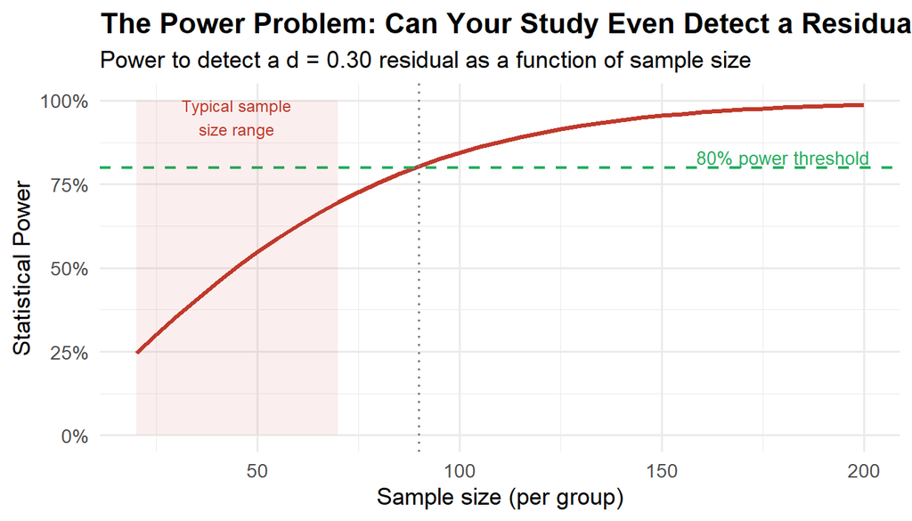

# 7 The Modern Solution: Equivalence Testing for Residuals

This is where `contrast_analysis()` departs from the traditional approach. Instead of hoping the residuals are “not significant” (which proves nothing), it uses **equivalence testing** (Lakens, 2017; Campbell, 2024) to affirmatively demonstrate that the residuals are *negligibly small*.

Equivalence testing flips the hypothesis. In NHST, the null hypothesis is “no effect” and you try to reject it. In equivalence testing, the null hypothesis is “the effect is *meaningful*” (i.e., larger than some bound you specify), and you try to reject *that*. If you succeed, you have positive evidence that the effect is trivially small.

The specific procedure used here is the **Two One-Sided Tests (TOST)** method. You pre-specify a bound (delta) — the largest residual effect you’d consider negligible. Then:

1. Test whether the residual is significantly *less* than +delta.
2. Test whether the residual is significantly *greater* than −delta.

If both one-sided tests are significant, the residual falls entirely within your equivalence bounds. You can conclude it is **equivalent to zero**.

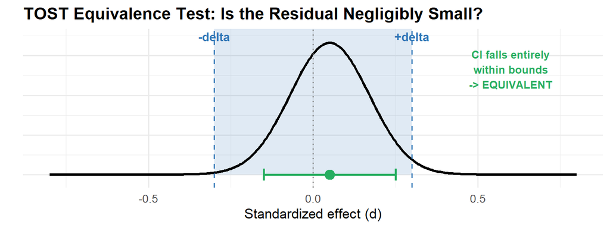

The blue shaded region is your “negligible zone” (±delta). If the confidence interval (green) falls entirely within it, you have positive statistical evidence that the residual is trivially small. This is a fundamentally different — and stronger — conclusion than “we failed to detect it.”

# 8 The Three Possible Conclusions

Putting both halves together, `contrast_analysis()` yields one of three conclusions:

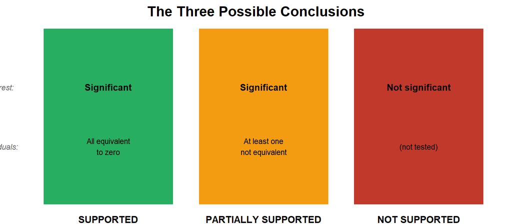

**SUPPORTED** means you have evidence for *both* claims: the predicted pattern exists, and there are no meaningful deviations from it.

**PARTIALLY SUPPORTED** means the predicted pattern exists, but the residuals can’t be ruled out as negligible. Something else is going on beyond your prediction.

**NOT SUPPORTED** means the predicted pattern itself isn’t statistically significant.

# 9 The Landscape: How Does This Relate to Other Tools?

Contrast analysis has a long history in psychology, and several R packages implement pieces of it. Understanding where `contrast_analysis()` fits in this landscape is useful.

**The `emmeans` approach** (Lenth, 2024) is perhaps the most widely used tool for contrasts in R today. It computes estimated marginal means and provides a flexible `contrast()` function that can test custom weight vectors. It is excellent for pairwise and custom comparisons, but it does not implement the full “interest + residuals” decomposition or equivalence testing.

**The `multcomp` approach** (Hothorn, Bretz, & Westfall, 2008) provides simultaneous inference for general parametric models via `glht()`. It supports custom contrast matrices and controls familywise error rates. Like `emmeans`, it does not include the residual decomposition or equivalence testing.

**The Schad et al. (2020) approach** provides a tutorial on contrast coding in linear mixed models. Their focus is on encoding hypotheses via contrast matrices in `lm()` and `lmer()`, not on the interest-vs-residual decomposition.

**The Granziol et al. (2025) approach** provides a tutorial on planned comparisons (including customized contrasts and interaction effects) with a companion Shiny app called “appRiori.” The app helps users understand the logic behind planned comparisons and generates R code for default and custom contrast coding. Their focus is on helping researchers specify and interpret planned contrasts in R, but it does not address the residual decomposition or equivalence testing.

**The `contrastanalysis` approach** integrates several ideas:

1. It builds the full set of orthogonal contrasts automatically (interest + residuals) from a single hypothesis vector.
2. It applies NHST to the interest contrast.
3. It applies TOST equivalence testing (following Campbell, 2024) to each residual contrast.
4. No alpha correction is needed across orthogonal contrasts.
5. It produces forest plots, variance decomposition, and APA output.

The contribution is the integration of these components into a coherent, one-function workflow that implements the full C+R logic correctly, replacing the problematic NHST residual test with equivalence testing.

# 10 Walkthrough 1: Violent Video Games and Aggression (Between-Subjects)

**The study.** A research team investigates the dose–response relationship between violent video game exposure and aggressive behavior. Participants are randomly assigned to one of four conditions: *No Exposure*, *Low Exposure* (1 hour), *Moderate Exposure* (3 hours), or *High Exposure* (5 hours). After the exposure, aggression is measured using a behavioral task (noise-blast paradigm). The team predicts a linear dose–response: more exposure → more aggression.

```r
set.seed(100)

n_per <- 60
vvg_data <- data.frame(
  condition = rep(c("NoExposure", "LowExposure", "ModExposure", "HighExposure"),
                  each = n_per),
  aggression = c(
    rnorm(n_per, mean = 3.0, sd = 2.8),
    rnorm(n_per, mean = 4.5, sd = 2.8),
    rnorm(n_per, mean = 6.0, sd = 2.8),
    rnorm(n_per, mean = 7.5, sd = 2.8)
  )
)
```

**Step 1: What would ANOVA tell us?**

```r
summary(aov(aggression ~ condition, data = vvg_data))
```

```
##              Df Sum Sq Mean Sq F value  Pr(>F)
## condition     3  583.1   194.4   28.99 5.4e-16 ***
## Residuals   236 1582.4     6.7
## ---
## Signif. codes:  0 '***' 0.001 '**' 0.01 '*' 0.05 '.' 0.1 ' ' 1
```

The ANOVA confirms that the group means differ — but it can’t tell us whether they differ *linearly*.

**Step 2: Run the contrast analysis.**

The hypothesis values encode a linear dose–response. We use the actual hours of exposure (0, 1, 3, 5) as weights, which tests whether aggression scales proportionally with dose:

```
##
## =================================================================
##       CONTRAST ANALYSIS WITH EQUIVALENCE TESTING
## =================================================================
##
## Design:  between-subjects
## Groups:  NoExposure, LowExposure, ModExposure, HighExposure (k = 4)
## N:       240
## Alpha:   0.05
## Orthogonal contrasts: Yes
## Effect size metric: d = b / sigma (b = contrast coefficient, sigma = sqrt(MSE))
##
## Hypothesized pattern: NoExposure < LowExposure < ModExposure < HighExposure
##
## ----- Contrast Weights -----
##                 InterestResidual 1Residual 2
##   NoExposure     -0.5859   -0.4703   -0.4308
##   LowExposure    -0.3255    0.2338    0.7677
##   ModExposure     0.1953    0.7083   -0.4585
##   HighExposure    0.7160   -0.4717    0.1216
##
##   Note: Residual contrasts are one possible orthonormal basis for the
##   subspace orthogonal to the predicted pattern. Individual residual
##   vectors are not uniquely defined, but their joint test is invariant:
##   if any systematic deviation from the predicted pattern exists, at
##   least one residual will detect it.
##
## ----- Contrast of Interest (NHST) -----
##   b = 3.095, SE = 0.334, t(236) = 9.259, p < .001 [SIGNIFICANT]
##   d = 1.195, 95% CI [0.941, 1.450]
##
## ----- Residual Contrasts (TOST Equivalence Tests) -----
##   Equivalence bounds (standardized): +/-0.300, +/-0.300
##
##   Residual 1:
##     Weights: NoExposure: -0.470, LowExposure: +0.234, ModExposure: +0.708, HighExposure: -0.472
##     NHST: b = 0.362, SE = 0.334, t(236) = 1.081, p = 0.281
##     TOST: d = 0.140, 90% CI [-0.074, 0.353]
##           p1 < .001, p2 = 0.108, p_TOST = 0.108 [NOT equivalent]
##
```

[output cut: 9 more lines]

```
##   Residual 2:           0.1%
##
## =================================================================
##   CONCLUSION: PARTIALLY SUPPORTED
## =================================================================
##   The data partially support the hypothesized pattern. The
##   contrast of interest is statistically significant, but not all
##   residual contrasts could be declared equivalent to zero. The
##   hypothesized pattern does not fully account for the
##   between-condition differences.
##
## ----- APA-Formatted Results -----
## Contrast of interest: b = 3.10, SE = 0.33, t(236) = 9.26, p < .001, d = 1.20, 95% CI [0.94, 1.45].
## Residual contrast 1 (TOST): b = 0.36, SE = 0.33, d = 0.14, 90% CI [-0.07, 0.35], equivalence bounds = +/-0.30, t1(236) = 3.41, p1 < .001, t2(236) = -1.24, p2 = .108, p_TOST = .108 (not equivalent to zero).
## Residual contrast 2 (TOST): b = 0.09, SE = 0.33, d = 0.03, 90% CI [-0.18, 0.25], equivalence bounds = +/-0.30, t1(236) = 2.58, p1 = .005, t2(236) = -2.07, p2 = .020, p_TOST = .020 (equivalent to zero).
```

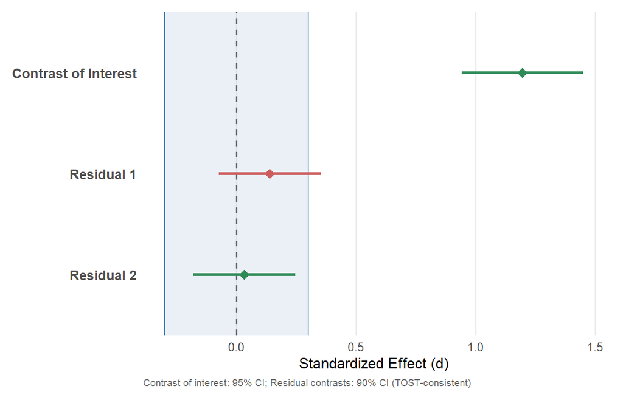

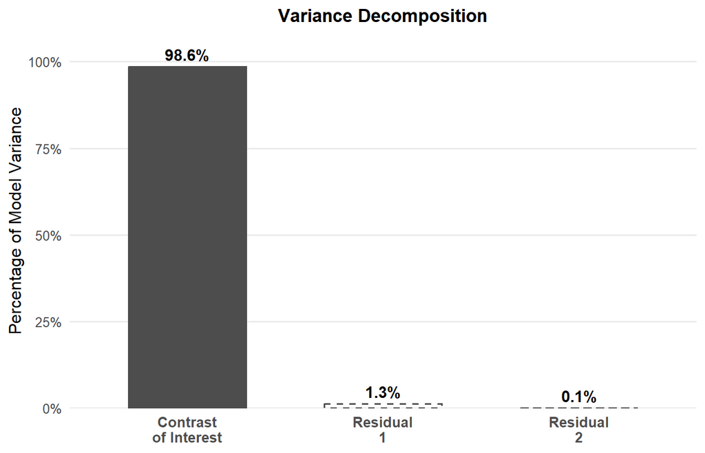

```r
result_vvg <- contrast_analysis(
  data       = vvg_data,
  dv         = "aggression",
  conditions = "condition",
  hypothesis = c(NoExposure = 0, LowExposure = 1,
                 ModExposure = 3, HighExposure = 5),
  delta      = 0.3,
  graph1     = TRUE,
  graph2     = TRUE
)
```

**Interpreting the results.**

The contrast of interest is highly significant, *t*(236) = 9.26, *p* < .001, with a large standardized effect of *d* = 1.20, 95% CI [0.94, 1.45]. This means there is a strong linear dose–response trend: aggression increases as exposure duration increases, exactly as the theory predicts.

But the conclusion is **PARTIALLY SUPPORTED**, not fully supported. Why? The variance decomposition shows that the linear trend accounts for 98.6% of the between-group variance — an overwhelming majority. However, the equivalence tests on the residual contrasts tell us that we cannot formally rule out all non-linear deviations as negligible. Residual 1 (*d* = 0.14) has a 90% CI of [−0.07, 0.35] that extends slightly beyond the ±0.30 equivalence bound, so the TOST fails to declare it equivalent (*p* = .108). Residual 2 (*d* = 0.03) is cleanly equivalent (*p* = .020).

In plain language: the dose–response relationship is overwhelmingly linear, but with *n* = 60 per group and these bounds, the study does not have quite enough precision to rule out every last trace of non-linearity. A larger sample or slightly wider bounds would likely yield full support.

**Step 3: The APA-ready write-up.**

```r
cat(result_vvg$apa)
```

```
## Contrast of interest: b = 3.10, SE = 0.33, t(236) = 9.26, p < .001, d = 1.20, 95% CI [0.94, 1.45].
## Residual contrast 1 (TOST): b = 0.36, SE = 0.33, d = 0.14, 90% CI [-0.07, 0.35], equivalence bounds = +/-0.30, t1(236) = 3.41, p1 < .001, t2(236) = -1.24, p2 = .108, p_TOST = .108 (not equivalent to zero).
## Residual contrast 2 (TOST): b = 0.09, SE = 0.33, d = 0.03, 90% CI [-0.18, 0.25], equivalence bounds = +/-0.30, t1(236) = 2.58, p1 = .005, t2(236) = -2.07, p2 = .020, p_TOST = .020 (equivalent to zero).
```

You can copy this directly into your results section.

# 11 Walkthrough 2: Emotional Intensity and Amygdala Response (Within-Subjects)

**The study.** In a neuroimaging experiment, 40 participants view faces displaying four levels of emotional intensity while undergoing fMRI: *Neutral*, *Subtle*, *Clear*, and *Intense*. The same participants see all four types (within-subjects design). The researcher predicts a threshold effect: amygdala activation stays flat for Neutral and Subtle, then jumps up for Clear and Intense. This is a **step function**: [Neutral = Subtle] < [Clear = Intense].

Note: Within-subjects data must be in **wide format** — one row per participant, one column per condition.

```r
set.seed(200)

n <- 40
Sigma_fmri <- matrix(0.25, nrow = 4, ncol = 4)
diag(Sigma_fmri) <- 1
Sigma_fmri <- 0.7^2 * Sigma_fmri

fmri_scores <- MASS::mvrnorm(n, mu = c(1.0, 1.1, 2.8, 2.9), Sigma = Sigma_fmri)

neuro_data <- data.frame(
  pid     = 1:n,
  Neutral = fmri_scores[, 1],
  Subtle  = fmri_scores[, 2],
  Clear   = fmri_scores[, 3],
  Intense = fmri_scores[, 4]
)

head(neuro_data)
```

```
##   pid   Neutral    Subtle    Clear  Intense
## 1   1 1.4350595 0.6146502 2.828258 2.765062
## 2   2 1.1034745 1.0421797 3.377240 1.857695
## 3   3 0.7235541 1.4367519 2.708925 2.129663
## 4   4 0.6880118 1.0761027 3.033330 1.969004
## 5   5 0.8001135 1.8192175 2.922935 2.147066
## 6   6 1.0193565 0.7238378 2.495450 3.773674
```

**The contrast analysis.**

```
##
## =================================================================
##       CONTRAST ANALYSIS WITH EQUIVALENCE TESTING
## =================================================================
##
## Design:  within-subjects
## Groups:  Neutral, Subtle, Clear, Intense (k = 4)
## N:       40
## Alpha:   0.05
## Orthogonal contrasts: Yes
## Effect size metric: d_z = M / SD (M and SD of within-subject contrast scores)
##
## Hypothesized pattern: [Neutral = Subtle] < [Clear = Intense]
##
## ----- Contrast Weights -----
##                 InterestResidual 1Residual 2
##   Neutral        -0.5000   -0.5000   -0.5000
##   Subtle         -0.5000    0.5000    0.5000
##   Clear           0.5000    0.5000   -0.5000
##   Intense         0.5000   -0.5000    0.5000
##
##   Note: Residual contrasts are one possible orthonormal basis for the
##   subspace orthogonal to the predicted pattern. Individual residual
##   vectors are not uniquely defined, but their joint test is invariant:
##   if any systematic deviation from the predicted pattern exists, at
##   least one residual will detect it.
##
## ----- Contrast of Interest (NHST) -----
##   b = 1.643, SE = 0.078, t(39) = 21.182, p < .001 [SIGNIFICANT]
##   d = 3.349, 95% CI [2.527, 4.171]
##
## ----- Residual Contrasts (TOST Equivalence Tests) -----
##   Equivalence bounds (standardized): +/-0.250, +/-0.250
##
##   Residual 1:
##     Weights: Neutral: -0.500, Subtle: +0.500, Clear: +0.500, Intense: -0.500
##     NHST: b = 0.089, SE = 0.093, t(39) = 0.954, p = 0.346
##     TOST: d = 0.151, 90% CI [-0.117, 0.419]
##           p1 = 0.008, p2 = 0.267, p_TOST = 0.267 [NOT equivalent]
##
```

[output cut: 9 more lines]

```
##   Residual 2:           0.1%
##
## =================================================================
##   CONCLUSION: PARTIALLY SUPPORTED
## =================================================================
##   The data partially support the hypothesized pattern. The
##   contrast of interest is statistically significant, but not all
##   residual contrasts could be declared equivalent to zero. The
##   hypothesized pattern does not fully account for the
##   between-condition differences.
##
## ----- APA-Formatted Results -----
## Contrast of interest: b = 1.64, SE = 0.08, t(39) = 21.18, p < .001, d = 3.35, 95% CI [2.53, 4.17].
## Residual contrast 1 (TOST): b = 0.09, SE = 0.09, d = 0.15, 90% CI [-0.12, 0.42], equivalence bounds = +/-0.25, t1(39) = 2.53, p1 = .008, t2(39) = -0.63, p2 = .267, p_TOST = .267 (not equivalent to zero).
## Residual contrast 2 (TOST): b = -0.06, SE = 0.08, d = -0.11, 90% CI [-0.38, 0.16], equivalence bounds = +/-0.25, t1(39) = 0.90, p1 = .188, t2(39) = -2.27, p2 = .015, p_TOST = .188 (not equivalent to zero).
```

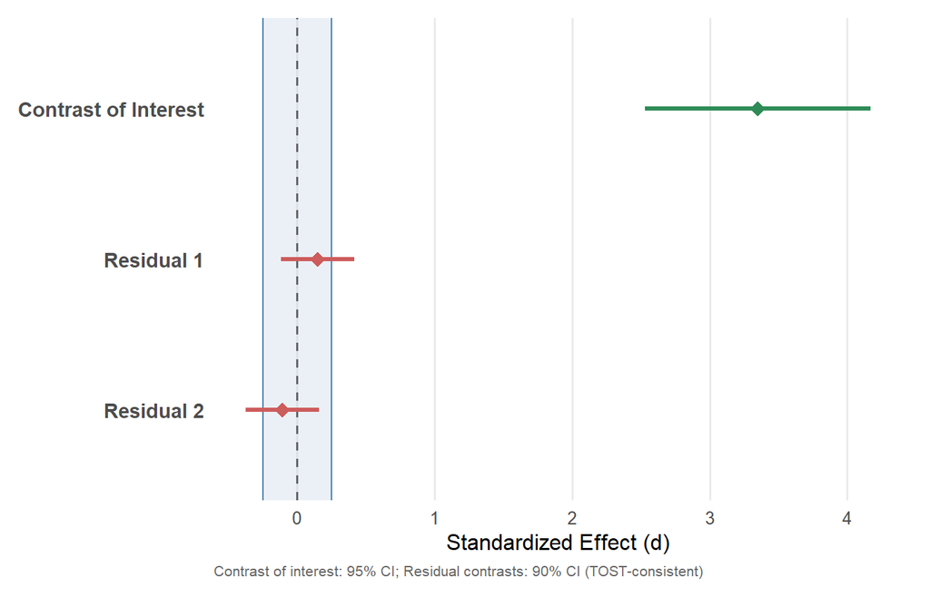

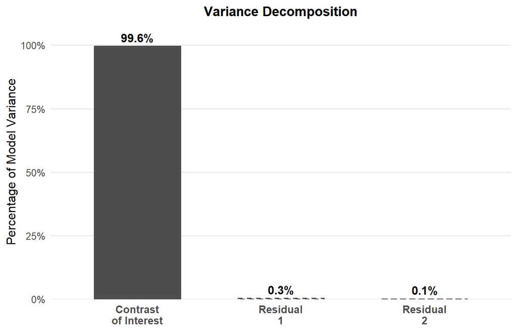

```r
result_neuro <- contrast_analysis(
  data       = neuro_data,
  dv         = NULL,
  conditions = NULL,
  hypothesis = c(Neutral = 0, Subtle = 0, Clear = 1, Intense = 1),
  design     = "within",
  id         = "pid",
  delta      = 0.25,
  graph1     = TRUE,
  graph2     = TRUE
)
```

**Interpreting the results.**

The step-function contrast is massively significant, *t*(39) = 21.18, *p* < .001, with an enormous within-subject effect size of *d*<sub>z</sub> = 3.35, 95% CI [2.53, 4.17]. The threshold jump from below-threshold to above-threshold stimuli is unmistakable.

Despite the residual effects being very small in absolute terms (*d* = 0.15 and *d* = −0.11), the equivalence tests cannot formally declare them negligible at the ±0.25 bound with only *n* = 40 (TOST *p* = .267 and *p* = .188, respectively). The conclusion is **PARTIALLY SUPPORTED**.

The practical interpretation is straightforward: the threshold model is an excellent description of the activation pattern (99.6% of variance), but the study was slightly underpowered to conclusively rule out tiny within-tier differences. A sample of 60–70 participants would likely provide enough precision to achieve full support.

```r
cat(result_neuro$apa)
```

```
## Contrast of interest: b = 1.64, SE = 0.08, t(39) = 21.18, p < .001, d = 3.35, 95% CI [2.53, 4.17].
## Residual contrast 1 (TOST): b = 0.09, SE = 0.09, d = 0.15, 90% CI [-0.12, 0.42], equivalence bounds = +/-0.25, t1(39) = 2.53, p1 = .008, t2(39) = -0.63, p2 = .267, p_TOST = .267 (not equivalent to zero).
## Residual contrast 2 (TOST): b = -0.06, SE = 0.08, d = -0.11, 90% CI [-0.38, 0.16], equivalence bounds = +/-0.25, t1(39) = 0.90, p1 = .188, t2(39) = -2.27, p2 = .015, p_TOST = .188 (not equivalent to zero).
```

# 12 Walkthrough 3: Learning Across Sessions (Within-Subjects)

**The study.** 55 participants complete a word recall task across five weekly sessions. The cognitive psychologist predicts a steady, linear improvement: each session should produce the same increment in recall accuracy.

```r
set.seed(300)

n <- 55
k <- 5
Sigma_learn <- matrix(0.5, k, k)
diag(Sigma_learn) <- 1
Sigma_learn <- 5^2 * Sigma_learn

learn_scores <- MASS::mvrnorm(n, mu = c(38, 46, 54, 62, 70), Sigma = Sigma_learn)

cog_data <- data.frame(
  pid     = 1:n,
  Week1   = learn_scores[, 1],
  Week2   = learn_scores[, 2],
  Week3   = learn_scores[, 3],
  Week4   = learn_scores[, 4],
  Week5   = learn_scores[, 5]
)
```

```
##
## =================================================================
##       CONTRAST ANALYSIS WITH EQUIVALENCE TESTING
## =================================================================
##
## Design:  within-subjects
## Groups:  Week1, Week2, Week3, Week4, Week5 (k = 5)
## N:       55
## Alpha:   0.05
## Orthogonal contrasts: Yes
## Effect size metric: d_z = M / SD (M and SD of within-subject contrast scores)
##
## Hypothesized pattern: Week1 < Week2 < Week3 < Week4 < Week5
##
## ----- Contrast Weights -----
##                 InterestResidual 1Residual 2Residual 3
##   Week1          -0.6325   -0.4149   -0.3626   -0.3104
##   Week2          -0.3162    0.0672    0.3996    0.7320
##   Week3           0.0000    0.8377   -0.2013   -0.2403
##   Week4           0.3162   -0.2174    0.6543   -0.4739
##   Week5           0.6325   -0.2726   -0.4900    0.2925
##
##   Note: Residual contrasts are one possible orthonormal basis for the
##   subspace orthogonal to the predicted pattern. Individual residual
##   vectors are not uniquely defined, but their joint test is invariant:
##   if any systematic deviation from the predicted pattern exists, at
##   least one residual will detect it.
##
## ----- Contrast of Interest (NHST) -----
##   b = 24.843, SE = 0.488, t(54) = 50.928, p < .001 [SIGNIFICANT]
##   d = 6.867, 95% CI [5.527, 8.207]
##
## ----- Residual Contrasts (TOST Equivalence Tests) -----
##   Equivalence bounds (standardized): +/-0.300, +/-0.300, +/-0.300
##
##   Residual 1:
##     Weights: Week1: -0.415, Week2: +0.067, Week3: +0.838, Week4: -0.217, Week5: -0.273
##     NHST: b = -0.650, SE = 0.502, t(54) = -1.296, p = 0.200
##     TOST: d = -0.175, 90% CI [-0.402, 0.053]
##           p1 = 0.179, p2 < .001, p_TOST = 0.179 [NOT equivalent]
```

[output cut: 18 more lines]

```
##
## =================================================================
##   CONCLUSION: PARTIALLY SUPPORTED
## =================================================================
##   The data partially support the hypothesized pattern. The
##   contrast of interest is statistically significant, but not all
##   residual contrasts could be declared equivalent to zero. The
##   hypothesized pattern does not fully account for the
##   between-condition differences.
##
## ----- APA-Formatted Results -----
## Contrast of interest: b = 24.84, SE = 0.49, t(54) = 50.93, p < .001, d = 6.87, 95% CI [5.53, 8.21].
## Residual contrast 1 (TOST): b = -0.65, SE = 0.50, d = -0.17, 90% CI [-0.40, 0.05], equivalence bounds = +/-0.30, t1(54) = 0.93, p1 = .179, t2(54) = -3.52, p2 < .001, p_TOST = .179 (not equivalent to zero).
## Residual contrast 2 (TOST): b = -0.30, SE = 0.51, d = -0.08, 90% CI [-0.31, 0.15], equivalence bounds = +/-0.30, t1(54) = 1.63, p1 = .054, t2(54) = -2.82, p2 = .003, p_TOST = .054 (not equivalent to zero).
## Residual contrast 3 (TOST): b = 0.17, SE = 0.53, d = 0.04, 90% CI [-0.18, 0.27], equivalence bounds = +/-0.30, t1(54) = 2.54, p1 = .007, t2(54) = -1.91, p2 = .031, p_TOST = .031 (equivalent to zero).
```

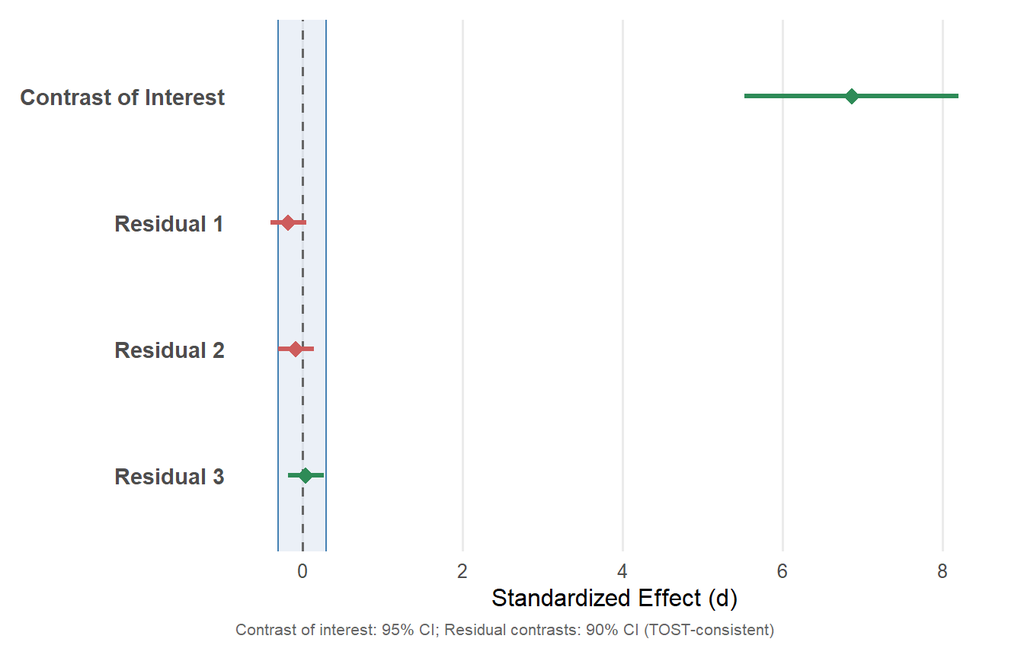

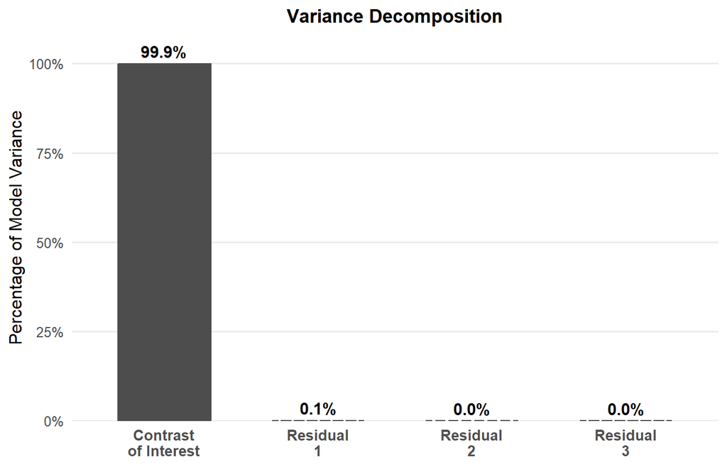

```r
result_cog <- contrast_analysis(
  data       = cog_data,
  dv         = NULL,
  conditions = NULL,
  hypothesis = c(Week1 = 1, Week2 = 2, Week3 = 3, Week4 = 4, Week5 = 5),
  design     = "within",
  id         = "pid",
  delta      = 0.3,
  graph1     = TRUE,
  graph2     = TRUE
)
```

**Interpreting the results.**

The linear trend is overwhelmingly significant, *t*(54) = 50.93, *p* < .001, with *d*<sub>z</sub> = 6.87, 95% CI [5.53, 8.21]. Recall improves massively across the five sessions, and 99.9% of the between-session variance is captured by the linear contrast.

With *k* = 5 conditions, there are 3 residual contrasts that collectively capture any non-linearity. Residual 3 is declared equivalent to zero (*d* = 0.04, TOST *p* = .031), but Residuals 1 and 2 are not (*p* = .179 and *p* = .054, respectively). The conclusion is therefore **PARTIALLY SUPPORTED**.

Note that all three residual effects are tiny (*d* = −0.17, −0.08, and 0.04), and the two that fail the TOST are borderline — Residual 2 misses the equivalence criterion by a hair (*p* = .054 vs. alpha = .05). This is a case where the data are *almost* fully linear, but the study with *n* = 55 doesn’t quite have the precision to formally certify it. With *n* = 75 or slightly wider equivalence bounds, the same data pattern would likely achieve full support.

The practical takeaway is still clear: learning is overwhelmingly linear across these five weeks, with no hint of a plateau or diminishing returns.

```r
cat(result_cog$apa)
```

```
## Contrast of interest: b = 24.84, SE = 0.49, t(54) = 50.93, p < .001, d = 6.87, 95% CI [5.53, 8.21].
## Residual contrast 1 (TOST): b = -0.65, SE = 0.50, d = -0.17, 90% CI [-0.40, 0.05], equivalence bounds = +/-0.30, t1(54) = 0.93, p1 = .179, t2(54) = -3.52, p2 < .001, p_TOST = .179 (not equivalent to zero).
## Residual contrast 2 (TOST): b = -0.30, SE = 0.51, d = -0.08, 90% CI [-0.31, 0.15], equivalence bounds = +/-0.30, t1(54) = 1.63, p1 = .054, t2(54) = -2.82, p2 = .003, p_TOST = .054 (not equivalent to zero).
## Residual contrast 3 (TOST): b = 0.17, SE = 0.53, d = 0.04, 90% CI [-0.18, 0.27], equivalence bounds = +/-0.30, t1(54) = 2.54, p1 = .007, t2(54) = -1.91, p2 = .031, p_TOST = .031 (equivalent to zero).
```

# 13 Walkthrough 4: Leadership Training in Organizations (Between-Subjects)

**The study.** An organizational psychologist evaluates three leadership training programs against an untreated control group. She predicts that all three programs are equally effective and superior to no training: [Control] < [ProgramA = ProgramB = ProgramC]. The outcome is a 360-degree leadership effectiveness rating collected three months post- training.

```r
set.seed(400)

n_per <- 45
org_data <- data.frame(
  group = rep(c("Control", "ProgramA", "ProgramB", "ProgramC"), each = n_per),
  effectiveness = c(
    rnorm(n_per, mean = 50, sd = 10),
    rnorm(n_per, mean = 62, sd = 10),
    rnorm(n_per, mean = 60, sd = 10),
    rnorm(n_per, mean = 64, sd = 10)
  )
)
```

**The contrast analysis.**

```
##
## =================================================================
##       CONTRAST ANALYSIS WITH EQUIVALENCE TESTING
## =================================================================
##
## Design:  between-subjects
## Groups:  Control, ProgramA, ProgramB, ProgramC (k = 4)
## N:       180
## Alpha:   0.05
## Orthogonal contrasts: Yes
## Effect size metric: d = b / sigma (b = contrast coefficient, sigma = sqrt(MSE))
##
## Hypothesized pattern: Control < [ProgramA = ProgramB = ProgramC]
##
## ----- Contrast Weights -----
##                 InterestResidual 1Residual 2
##   Control        -0.8660   -0.0000    0.0000
##   ProgramA        0.2887   -0.5774   -0.5774
##   ProgramB        0.2887    0.7887   -0.2113
##   ProgramC        0.2887   -0.2113    0.7887
##
##   Note: Residual contrasts are one possible orthonormal basis for the
##   subspace orthogonal to the predicted pattern. Individual residual
##   vectors are not uniquely defined, but their joint test is invariant:
##   if any systematic deviation from the predicted pattern exists, at
##   least one residual will detect it.
##
## ----- Contrast of Interest (NHST) -----
##   b = 11.095, SE = 1.440, t(176) = 7.708, p < .001 [SIGNIFICANT]
##   d = 1.149, 95% CI [0.855, 1.443]
##
## ----- Residual Contrasts (TOST Equivalence Tests) -----
##   Equivalence bounds (standardized): +/-0.300, +/-0.300
##
##   Residual 1:
##     Weights: Control: -0.000, ProgramA: -0.577, ProgramB: +0.789, ProgramC: -0.211
##     NHST: b = 1.790, SE = 1.440, t(176) = 1.243, p = 0.215
##     TOST: d = 0.185, 90% CI [-0.061, 0.432]
##           p1 < .001, p2 = 0.221, p_TOST = 0.221 [NOT equivalent]
##
```

[output cut: 9 more lines]

```
##   Residual 2:           0.7%
##
## =================================================================
##   CONCLUSION: PARTIALLY SUPPORTED
## =================================================================
##   The data partially support the hypothesized pattern. The
##   contrast of interest is statistically significant, but not all
##   residual contrasts could be declared equivalent to zero. The
##   hypothesized pattern does not fully account for the
##   between-condition differences.
##
## ----- APA-Formatted Results -----
## Contrast of interest: b = 11.10, SE = 1.44, t(176) = 7.71, p < .001, d = 1.15, 95% CI [0.85, 1.44].
## Residual contrast 1 (TOST): b = 1.79, SE = 1.44, d = 0.19, 90% CI [-0.06, 0.43], equivalence bounds = +/-0.30, t1(176) = 3.26, p1 < .001, t2(176) = -0.77, p2 = .221, p_TOST = .221 (not equivalent to zero).
## Residual contrast 2 (TOST): b = 0.97, SE = 1.44, d = 0.10, 90% CI [-0.15, 0.35], equivalence bounds = +/-0.30, t1(176) = 2.69, p1 = .004, t2(176) = -1.34, p2 = .091, p_TOST = .091 (not equivalent to zero).
```

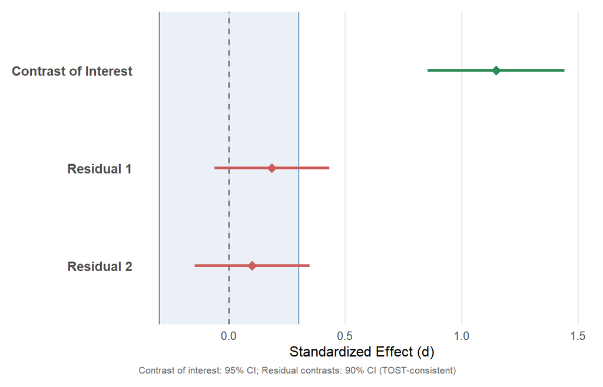

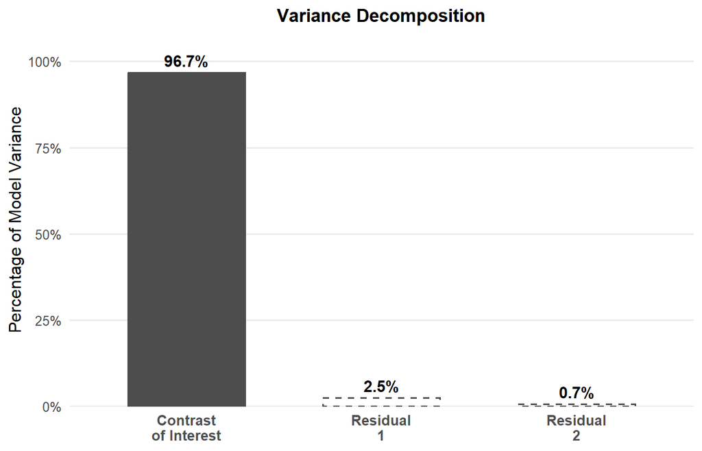

```r
result_org <- contrast_analysis(
  data       = org_data,
  dv         = "effectiveness",
  conditions = "group",
  hypothesis = c(Control = 0, ProgramA = 1, ProgramB = 1, ProgramC = 1),
  delta      = 0.3,
  graph1     = TRUE,
  graph2     = TRUE
)
```

**Interpreting the results.**

The interest contrast is significant, *t*(176) = 7.71, *p* < .001, *d* = 1.15, 95% CI [0.85, 1.44]. The training programs, as a group, are substantially more effective than the control condition — a large and practically meaningful effect.

The variance decomposition shows the interest contrast accounts for 96.7% of the between-group variance. But the residuals — which here test whether the three programs differ *from each other* — account for the remaining 3.2%. Residual 1 (*d* = 0.19) and Residual 2 (*d* = 0.10) both fail the equivalence test (*p* = .221 and *p* = .091). The conclusion is **PARTIALLY SUPPORTED**.

This is a good example of how the PARTIALLY SUPPORTED conclusion provides genuinely useful diagnostic information that neither ANOVA nor post-hoc tests would surface as cleanly.

```r
cat(result_org$apa)
```

```
## Contrast of interest: b = 11.10, SE = 1.44, t(176) = 7.71, p < .001, d = 1.15, 95% CI [0.85, 1.44].
## Residual contrast 1 (TOST): b = 1.79, SE = 1.44, d = 0.19, 90% CI [-0.06, 0.43], equivalence bounds = +/-0.30, t1(176) = 3.26, p1 < .001, t2(176) = -0.77, p2 = .221, p_TOST = .221 (not equivalent to zero).
## Residual contrast 2 (TOST): b = 0.97, SE = 1.44, d = 0.10, 90% CI [-0.15, 0.35], equivalence bounds = +/-0.30, t1(176) = 2.69, p1 = .004, t2(176) = -1.34, p2 = .091, p_TOST = .091 (not equivalent to zero).
```

# 14 A Note on Mixed Designs

All examples above are either purely between-subjects or purely within-subjects. The `contrast_analysis()` function does not currently support **mixed designs** (experiments with both a between-subjects and a within-subjects factor). This is a planned feature for a future release.

# 15 Resources

**Papers:**

- Richter, M. (2016). Residual tests in the analysis of planned contrasts: Problems and solutions. *Psychological Methods*, *21*(1), 112–120. https://doi.org/10.1037/met0000044
- Lakens, D. (2017). Equivalence tests: A practical primer. *Social Psychological and Personality Science*, *8*(4), 355–362.
- Campbell, H. (2024). Equivalence testing for linear regression. *Psychological Methods*, *29*(1), 88–98. https://doi.org/10.1037/met0000596
- Schad, D. J., Vasishth, S., Hohenstein, S., & Kliegl, R. (2020). How to capitalize on a priori contrasts in linear (mixed) models: A tutorial. *Journal of Memory and Language*, *110*, 104038. https://doi.org/10.1016/j.jml.2019.104038
- Granziol, U., Rabe, M., Gallucci, M., Spoto, A., & Vidotto, G. (2025). Not another post hoc paper: A new look at contrast analysis and planned comparisons. *Advances in Methods and Practices in Psychological Science*, *8*(1), Article 25152459241293110. https://doi.org/10.1177/25152459241293110
- Steiger, J. H. (2004). Beyond the F test: Effect size confidence intervals and tests of close fit in the analysis of variance and contrast analysis. *Psychological Methods*, *9*(2), 164–182. https://doi.org/10.1037/1082-989X.9.2.164

**R packages:**

- **`emmeans`** — Estimated marginal means with flexible contrast functions. [CRAN](https://cran.r-project.org/package=emmeans) | [Contrasts vignette](https://cran.r-project.org/web/packages/emmeans/vignettes/comparisons.html)
- **`multcomp`** — Simultaneous inference in general parametric models. [CRAN](https://cran.r-project.org/package=multcomp) | [Manual (PDF)](https://cran.r-project.org/web/packages/multcomp/multcomp.pdf)
- **`rempsyc`** — Psychology-oriented helper functions including `nice_contrasts()`. [CRAN](https://cran.r-project.org/package=rempsyc) | [Contrasts tutorial](https://rempsyc.remi-theriault.com/articles/contrasts)
- **`TOSTER`** — Daniel Lakens’ package for equivalence testing. [CRAN](https://cran.r-project.org/package=TOSTER)
- **`contrastanalysis`** — This package. [GitHub](https://github.com/Y45HV1N/contrastanalysis) | [Online docs](https://Y45HV1N.github.io/contrastanalysis/)

**Tutorials and lectures:**

- Meier, L. — *Contrasts and Multiple Testing* (ETH Zurich). [Link](https://people.math.ethz.ch/~meier/teaching/anova/contrasts-and-multiple-testing.html)
- Seltman, H. — *Lecture 8: Contrasts and Multiple Comparisons* (CMU). [Link](https://www.stat.cmu.edu/~hseltman/309/lectures/Lec8-4up.pdf)
- Ariya, K. — *Lab 05: Multiple Comparisons*. Step-by-step `emmeans` example. [Link](https://kris-ariya.github.io/r-tutorials/EXPRM_Lab05.html)
- UVA Library — *Understanding Multiple Comparisons*. [Link](http://library.virginia.edu/data/articles/understanding-multiple-comparisons-and-simultaneous-inference)

**The `contrastanalysis` package tutorials:**

- **Main tutorial:** `vignette("tutorial", package = "contrastanalysis")`
- **Designs tutorial:** `vignette("designs_tutorial", package = "contrastanalysis")`
- **Online:** https://Y45HV1N.github.io/contrastanalysis/